# noise_removal

**Signal Processing Techniques for Noise Removal, Applied to Audio Wav Files from my BirdNet-Pi setup.**

**Shreya Narayan**

```python
import numpy as np
import matplotlib.pyplot as plt
import librosa
import scipy.signal as signal
from scipy.signal import wiener
import soundfile as sf
from scipy.ndimage import median_filter
```

Bird vocalizations are normally narrowband / harmonic, non-stationary, and concentrated above low frequency traffic noise. Car noise is usually low frequency dominant and broadband but slowly varying. As a car passes the microphone, the amplitude and frequency increases, consistent with the doppler effect.

```python
# Load Audio
audio_path = "waveFiles/Annas_Hummingbird-77-2026-05-17-birdnet-17_39_21.mp3"
data, sr = librosa.load(audio_path, sr = None) # y = audio time series. sr = sampling rate of y

print('sampling rate: ', sr)
print(len(data)/sr) # number of seconds displayed
print(len(data)) # each wav file is 6 seconds long
```

```
sampling rate:  48000
6.024
289152
```

**Baseline Spectrogram**

```python
def plotSpecgram(data, sr, title, saveBool, savePath = None):
    """
    Plot a spectrogram of a time series data steam.
    Inputs:
    data: time series
    sr = sampling rate
    title = title of plot
    saveBool = boolean for saving the figure or not
    saevPath = name of figure / path to save to. (include .png as file extension)
    """
    plt.figure(figsize=(9,5))

    amplitudeDB = librosa.amplitude_to_db(np.abs(librosa.stft(data)), ref = np.max)

    librosa.display.specshow(amplitudeDB, sr = sr, x_axis = 'time', y_axis = 'hz', cmap = 'magma')
    plt.colorbar(format = '%+2.0f dB')
    plt.title(title)
    plt.xlabel('Time (sec)')
    plt.ylabel('Frequency (Hz)')
    plt.tight_layout()
    plt.ylim((0, 16000))

    if saveBool:
        plt.savefig(savePath)

    plt.show()
    return
```

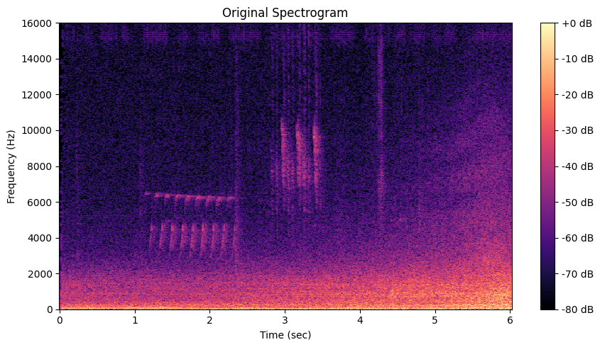

```python
# Baseline Spectrogram
plotSpecgram(data, sr, title='Original Spectrogram', saveBool=True, savePath='originalSpectrogram.png')
```

Upper frequency bound shown above is 16 kHz, because the frequency response of my Lavlier microphone is from 20 Hz to 16 kHz.

**High Pass Filter**

Car noise is strongest below 1 - 2kHZ. We can see that our bird signal is between 2 kHZ - 12 kHz. We will use a Butterworth filter, which has mazimally flat magnitude response in the passband (with a tradeoff of a slower roll-off).

```python
# High Pass Butterworth Filter
def hpf(data, cutoff, sr, order = 5):
    """
    High Pass Butterworth Filter
    data = time series data
    cutoff = our cutoff - we pass frequencies above this.
    sr = sampling rate
    order = order of the butterworth filter.
    """
    nyquist = 0.5 * sr # We need to sample at twice the max frequency we want to be able to detect.
    normal_cutoff = cutoff / nyquist

    b, a = signal.butter(order, normal_cutoff, btype = 'high')

    # apply digital filter forward and backward, for 0 phase distortion and twice original filter order for steeper roll off.
    # Eliminates time delays and phase distortion caused by standard forward pass filters.
    HPfiltered = signal.filtfilt(b, a, data)

    return HPfiltered

def bandpassFilter(data, lowcut, highcut, sr, order=5):
    """
    Bandpass Butterworth Filter
    """
    nyquist = 0.5 * sr
    low = lowcut / nyquist
    high = highcut / nyquist

    b, a = signal.butter(order, [low, high], btype='band')

    BPfiltered = signal.filtfilt(b, a, data)

    return BPfiltered
```

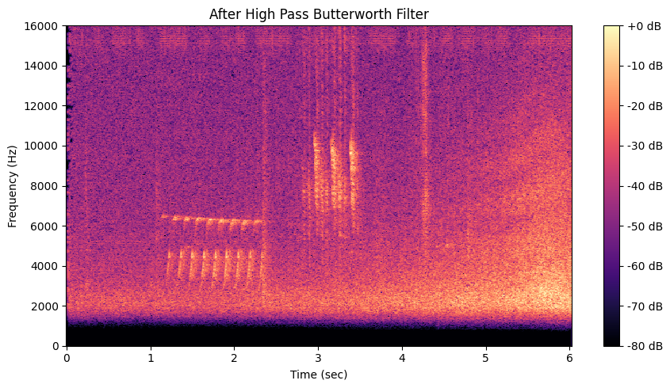

```python
# Apply HPF, Save wave file, and plot spectrogram
hp_audio = hpf(data, cutoff=2000, sr = sr)
sf.write("highpass.wav", hp_audio, sr)
plotSpecgram(hp_audio, sr, 'After High Pass Butterworth Filter', True, 'highPass.png')
```

**Bandpass Filter**

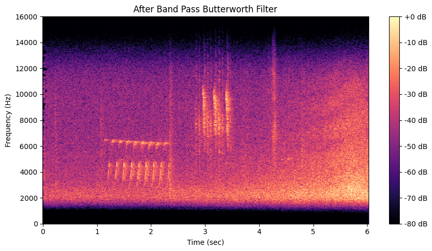

```python
# Bandpass Butterworth Filter
bp_audio = bandpassFilter(data, 2000, 12000, sr)
sf.write("bandpass.wav", bp_audio, sr)
plotSpecgram(bp_audio, sr, 'After Band Pass Butterworth Filter', True, 'bandpass.png')
```

These frequency domain filters remove our low frequency noise well and top end high frequency noise well. However, the frequencies of the car moving past the microphone are still well within our passband.

**Spectral Subtraction**

We can estimate the noise spectrum and subtract it from the signal. This works best when noise is stationary.

```python
# Spectral Subtraction
def spectralSubtraction(data, sr, noise_start, noise_end,
                        subtraction_start, subtraction_end, alpha = 1):
    """
    Subtract noise spectrum.
    alpha = weighting of noise profile

    """
    # STFT
    stft = librosa.stft(data)
    magnitude = np.abs(stft) # shape: (frequency bins, time frames)
    phase = np.angle(stft)

    # Convert noise start to end to frames in the data
    noise_start_frame = librosa.time_to_frames(noise_start, sr = sr)
    noise_end_frame = librosa.time_to_frames(noise_end, sr = sr)

    subtraction_frame_start = librosa.time_to_frames(subtraction_start, sr = sr)
    subtraction_frame_end = librosa.time_to_frames(subtraction_end, sr = sr)

    # Index into those noise frames and get info about mean noise value
    noiseFrames = magnitude[:, noise_start_frame:noise_end_frame]
    noiseProfile = np.mean(noiseFrames, axis = 1, keepdims=True)

    # Only Subtract after the bird vocalization - when the car overtakes the audio
    clean_mag = magnitude.copy()
    clean_mag[:, subtraction_frame_start:subtraction_frame_end] = (clean_mag[:, subtraction_frame_start:subtraction_frame_end] -
                                                                   alpha * noiseProfile)

    clean_mag = np.maximum(clean_mag, 0)

    # Reconstruct
    reconstructed = clean_mag * np.exp(1j * phase)
    spectral_sub_audio = librosa.istft(reconstructed)

    # sf.write(waveFileName, spectral_sub_audio, sr)

    return spectral_sub_audio
```

Given that we know the car is passing at the end of the audio clip, we can selectively remove noise from that region.

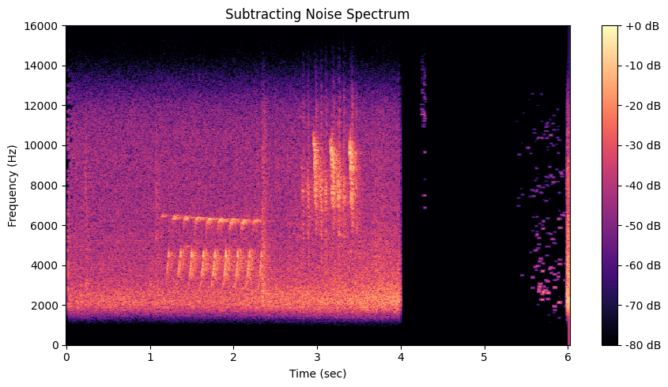

```python
spectral_sub_audio_end = spectralSubtraction(data = bp_audio, sr = sr, noise_start = 5, noise_end = 6.024,
                                         subtraction_start = 4, subtraction_end=6, alpha = 3)
plotSpecgram(spectral_sub_audio_end, sr, "Subtracting Noise Spectrum", True, 'spectral_subtraction_end.png')
sf.write("spectral_sub_audio_end.wav", spectral_sub_audio_end, sr )
```

Let's remove background noise from the entire clip.

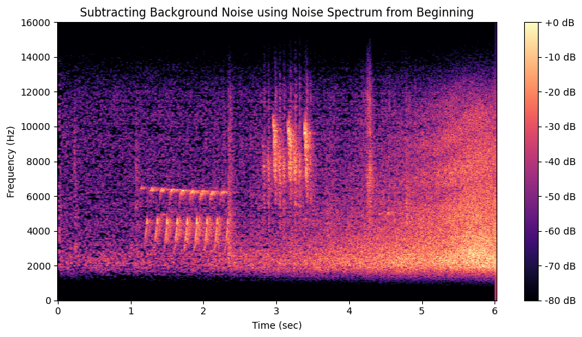

```python
spectral_sub_audio = spectralSubtraction(data = bp_audio, sr = sr, noise_start = 0, noise_end = 0.5,
                                         subtraction_start = 0, subtraction_end=6, alpha = 1.0)
plotSpecgram(spectral_sub_audio, sr, "Subtracting Background Noise using Noise Spectrum from Beginning", True, 'spectral_subtraction_beginning.png')
sf.write('background_noise_removal.wav', spectral_sub_audio, sr)
```

We can increase alpha to be a higher weight for subtraction.

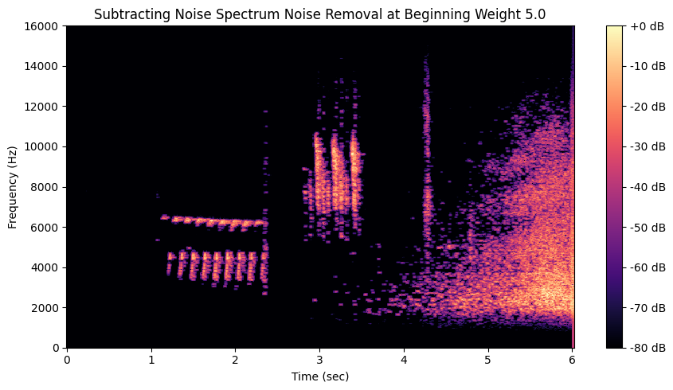

```python
spectral_sub_audio_higher_weight = spectralSubtraction(data = bp_audio, sr = sr, noise_start = 0, noise_end = 0.5,
                                         subtraction_start = 0, subtraction_end=6, alpha = 5.0)
plotSpecgram(spectral_sub_audio_higher_weight, sr, "Subtracting Noise Spectrum Noise Removal at Beginning Weight 5.0", True, 'spectral_subtraction_beginning_weight_2.png')
sf.write('background_noise_removal_weight_5.wav', spectral_sub_audio_higher_weight, sr )
```

We can remove nearly all of the noise in the first 4 seconds of the clip. But the car noise at the end remains.

The second one (where we subtract noise from the first 0.5 seconds of the clip) removes backround noise from the beginning throughout the audio clip. Note how clean the audio clip now sounds at the beginning.

If there is knowledge about the car in relation to the bird at the end of the audio clip, we can weight and remove that section highly.

Spectral subtraction works best on stationary noise sources, like background noise.

**Wiener Filter**

The Wiener filter reduces noise by utilizing statistical models of both the target signal and noise. It attempts to minimize overal mean squared error between estiamted output and the true, uncorrupted signal.

Suppresses signals with low SNR, and preserves frequencies with high SNR.

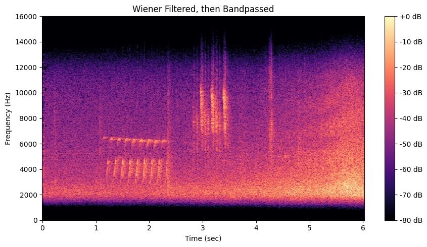

```python
# Weiner Filter:
wiener_audio = wiener(data)
bp_wiener_audio = bandpassFilter(wiener_audio, 2000, 12000, sr)
plotSpecgram(bp_wiener_audio, sr, "Wiener Filtered, then Bandpassed", True, 'wiener_filtered_on_raw_then_BP.png')
sf.write("wiener_filter_on_raw_then_BP.wav", bp_wiener_audio, sr)
```

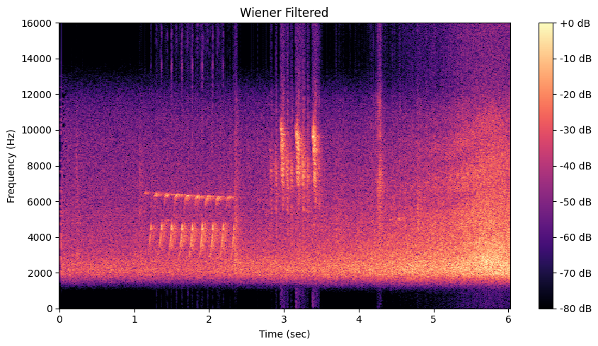

```python
# Wiener filter on BP - switch the order of the filters
wiener_audio = wiener(bp_audio)

plotSpecgram(wiener_audio, sr, "Wiener Filtered", True, 'wiener_filtered_on_bandpassed.png')
sf.write("wiener_filter_on_bandpassed.wav", wiener_audio, sr)
```

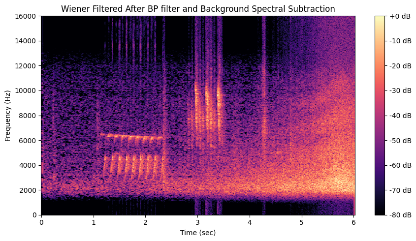

```python
# Wiener Filter on background noise spectral subtraction
wiener_audio = wiener(spectral_sub_audio)
plotSpecgram(wiener_audio, sr, "Wiener Filtered After BP filter and Background Spectral Subtraction", True, 'wiener_filtered_on_spectral_sub.png')
sf.write("wiener_filter_on_spectral_sub.wav", wiener_audio, sr)
```

Note the artifact frequencies that re-emerge in the previously removed frequency bands (< 2kHz, > 12kHz). The Wiener filter calculates a signal based on local power and noise statistics, which can reintroduce power if the initial BP filter doesn't achieve infinite attenuation (i.e, the filter has roll off).

The Wiener filter assumes stationary noise, so doesn't work well for the car at the end, whose signal is quite strong.

**Median Filter**

Apply a sliding window over the data and replace the center value with the median of all values in the window. Effective against salt and pepper noise.

```python
def medianFilter(data):
    stft = librosa.stft(data)
    mag = np.abs(stft)
    phase = np.angle(stft)

    filtered_mag = median_filter(mag, size = (1,5))

    reconstructed  = filtered_mag * np.exp(1j * phase)
    median_audio = librosa.istft(reconstructed)

    return median_audio
```

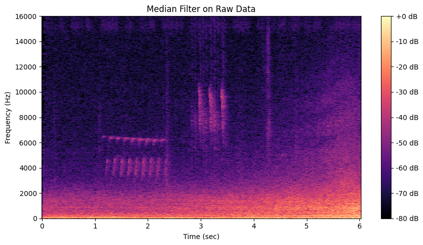

```python
medianAudio = medianFilter(data)
plotSpecgram(medianAudio, sr, 'Median Filter on Raw Data', True, 'median_filter_on_raw.png')
sf.write('medianFilterOnRaw.wav', medianAudio, sr)
```

Notice the blurring effect / removal of 'salt and pepper noise'.

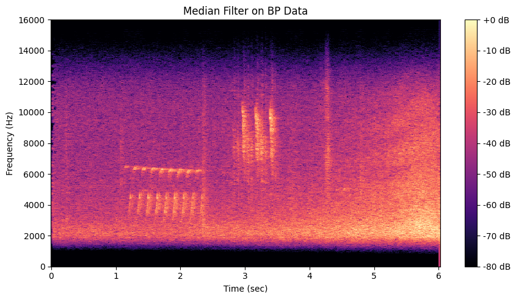

```python
medianAudio_BP = medianFilter(bp_audio)
plotSpecgram(medianAudio_BP, sr, 'Median Filter on BP Data', True, 'median_filter_on_BP.png')
sf.write('medianFilterOnBP.wav', medianAudio_BP, sr)
```

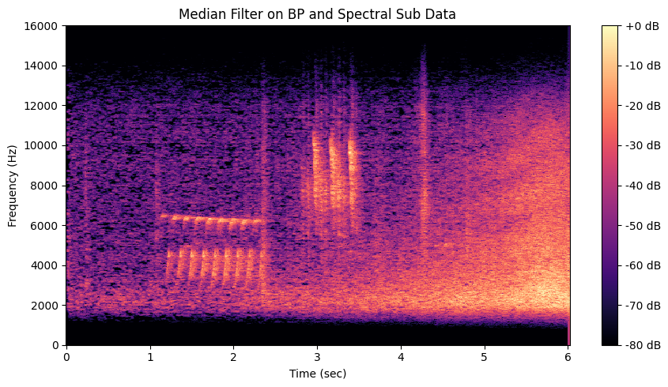

```python
medianAudio_Spec_sub = medianFilter(spectral_sub_audio)
plotSpecgram(medianAudio_Spec_sub, sr, 'Median Filter on BP and Spectral Sub Data', True, 'median_filter_on_BP_spec_sub.png')
sf.write('medianFilterOn_Spec_Sub.wav', medianAudio_Spec_sub, sr)
```

Still getting noise from car at the end. This makes sense because the car's noise in passing isn't a spike - it is a gradual increase in signal amplitude and frequency over 2 seconds.

**Noise Gating**

Remove signal that is below a particular threshold. Only lets through sounds that are over a particular threshold.

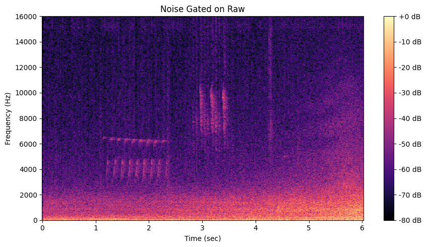

```python
threshold = 0.0007
gated = np.where(np.abs(data) < threshold, 0, data)

plotSpecgram(gated, sr, "Noise Gated on Raw", True, 'noise_gated_on_raw.png')
sf.write(f"noise_gated_on_raw_{threshold}.wav", gated, sr)
```

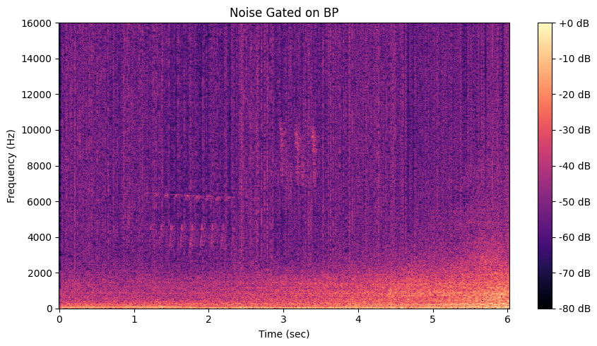

```python
threshold = 0.00001
gatedBP = np.where(np.abs(bp_audio) < threshold, 0, data)

plotSpecgram(gatedBP, sr, "Noise Gated on BP", True, 'noise_gated_on_bp.png')
sf.write(f"noise_gated_on_BP_{threshold}.wav", gatedBP, sr)
```

Noise Gating doesn't work that well because the car is so loud at the end. If we increase the threshold too much, the signal starts to be affected.